# Risk Factor Analysis

## Outcome Variable

**Outcome Variable:** stunted

## Predictor Variables

**Intervention Variable:** tr

**Adjustment Set:**

unadjusted

## Stratifying Variables

The analysis was stratified on these variable(s):

- birthlen
- agecat
- studyid
- country

## Data Summary

| birthlen | agecat | studyid | country | tr | stunted | n_cell | n |
| --- | --- | --- | --- | --- | --- | --- | --- |
| [-2–1) | Birth | ki1000125-AgaKhanUniv | PAKISTAN | Control | 0 | 3 | 3 |
| [-2–1) | 6 months | ki1000125-AgaKhanUniv | PAKISTAN | Control | 0 | 2 | 3 |
| [-2–1) | 6 months | ki1000125-AgaKhanUniv | PAKISTAN | Control | 1 | 1 | 3 |
| >=0 | Birth | ki1000125-AgaKhanUniv | PAKISTAN | Control | 0 | 1 | 4 |
| >=0 | Birth | ki1000125-AgaKhanUniv | PAKISTAN | Maternal | 0 | 3 | 4 |
| >=0 | 6 months | ki1000125-AgaKhanUniv | PAKISTAN | Control | 0 | 1 | 4 |
| >=0 | 6 months | ki1000125-AgaKhanUniv | PAKISTAN | Control | 1 | 0 | 4 |
| >=0 | 6 months | ki1000125-AgaKhanUniv | PAKISTAN | Maternal | 0 | 2 | 4 |
| >=0 | 6 months | ki1000125-AgaKhanUniv | PAKISTAN | Maternal | 1 | 1 | 4 |
| [-1-0) | Birth | ki1000125-AgaKhanUniv | PAKISTAN | Control | 0 | 3 | 4 |
| [-1-0) | Birth | ki1000125-AgaKhanUniv | PAKISTAN | Maternal | 0 | 1 | 4 |
| [-1-0) | 6 months | ki1000125-AgaKhanUniv | PAKISTAN | Control | 0 | 2 | 4 |
| [-1-0) | 6 months | ki1000125-AgaKhanUniv | PAKISTAN | Control | 1 | 1 | 4 |
| [-1-0) | 6 months | ki1000125-AgaKhanUniv | PAKISTAN | Maternal | 0 | 1 | 4 |
| [-1-0) | 6 months | ki1000125-AgaKhanUniv | PAKISTAN | Maternal | 1 | 0 | 4 |
| [-1-0) | 6 months | ki1000304b-SAS-CompFeed | INDIA | Control | 0 | 91 | 207 |
| [-1-0) | 6 months | ki1000304b-SAS-CompFeed | INDIA | Control | 1 | 16 | 207 |
| [-1-0) | 6 months | ki1000304b-SAS-CompFeed | INDIA | Other | 0 | 86 | 207 |
| [-1-0) | 6 months | ki1000304b-SAS-CompFeed | INDIA | Other | 1 | 14 | 207 |
| [-2–1) | 6 months | ki1000304b-SAS-CompFeed | INDIA | Control | 0 | 62 | 186 |
| [-2–1) | 6 months | ki1000304b-SAS-CompFeed | INDIA | Control | 1 | 27 | 186 |
| [-2–1) | 6 months | ki1000304b-SAS-CompFeed | INDIA | Other | 0 | 69 | 186 |
| [-2–1) | 6 months | ki1000304b-SAS-CompFeed | INDIA | Other | 1 | 28 | 186 |
| [-1-0) | Birth | ki1000304b-SAS-CompFeed | INDIA | Control | 0 | 28 | 46 |
| [-1-0) | Birth | ki1000304b-SAS-CompFeed | INDIA | Other | 0 | 18 | 46 |
| <-3 | Birth | ki1000304b-SAS-CompFeed | INDIA | Control | 1 | 4 | 11 |
| <-3 | Birth | ki1000304b-SAS-CompFeed | INDIA | Other | 1 | 7 | 11 |
| <-3 | 6 months | ki1000304b-SAS-CompFeed | INDIA | Control | 0 | 1 | 32 |
| <-3 | 6 months | ki1000304b-SAS-CompFeed | INDIA | Control | 1 | 11 | 32 |
| <-3 | 6 months | ki1000304b-SAS-CompFeed | INDIA | Other | 0 | 3 | 32 |

[output cut: 264 more lines]

The following strata were considered:

- birthlen: [-1-0), agecat: 24 months, studyid: ki1119695-PROBIT, country: BELARUS
- birthlen: [-1-0), agecat: 24 months, studyid: ki1126311-ZVITAMBO, country: ZIMBABWE
- birthlen: [-1-0), agecat: 24 months, studyid: kiGH5241-JiVitA-3, country: BANGLADESH
- birthlen: [-1-0), agecat: 24 months, studyid: kiGH5241-JiVitA-4, country: BANGLADESH
- birthlen: [-1-0), agecat: 6 months, studyid: ki1000125-AgaKhanUniv, country: PAKISTAN
- birthlen: [-1-0), agecat: 6 months, studyid: ki1000304b-SAS-CompFeed, country: INDIA
- birthlen: [-1-0), agecat: 6 months, studyid: ki1017093b-PROVIDE, country: BANGLADESH
- birthlen: [-1-0), agecat: 6 months, studyid: ki1119695-PROBIT, country: BELARUS
- birthlen: [-1-0), agecat: 6 months, studyid: ki1126311-ZVITAMBO, country: ZIMBABWE
- birthlen: [-1-0), agecat: 6 months, studyid: ki1135781-COHORTS, country: GUATEMALA
- birthlen: [-1-0), agecat: 6 months, studyid: kiGH5241-JiVitA-3, country: BANGLADESH
- birthlen: [-1-0), agecat: 6 months, studyid: kiGH5241-JiVitA-4, country: BANGLADESH
- birthlen: [-1-0), agecat: Birth, studyid: ki1000125-AgaKhanUniv, country: PAKISTAN
- birthlen: [-1-0), agecat: Birth, studyid: ki1000304b-SAS-CompFeed, country: INDIA
- birthlen: [-1-0), agecat: Birth, studyid: ki1119695-PROBIT, country: BELARUS
- birthlen: [-1-0), agecat: Birth, studyid: ki1126311-ZVITAMBO, country: ZIMBABWE
- birthlen: [-1-0), agecat: Birth, studyid: ki1135781-COHORTS, country: GUATEMALA
- birthlen: [-1-0), agecat: Birth, studyid: kiGH5241-JiVitA-3, country: BANGLADESH
- birthlen: [-1-0), agecat: Birth, studyid: kiGH5241-JiVitA-4, country: BANGLADESH
- birthlen: [-2–1), agecat: 24 months, studyid: ki1119695-PROBIT, country: BELARUS
- birthlen: [-2–1), agecat: 24 months, studyid: ki1126311-ZVITAMBO, country: ZIMBABWE
- birthlen: [-2–1), agecat: 24 months, studyid: kiGH5241-JiVitA-3, country: BANGLADESH
- birthlen: [-2–1), agecat: 24 months, studyid: kiGH5241-JiVitA-4, country: BANGLADESH
- birthlen: [-2–1), agecat: 6 months, studyid: ki1000125-AgaKhanUniv, country: PAKISTAN
- birthlen: [-2–1), agecat: 6 months, studyid: ki1000304b-SAS-CompFeed, country: INDIA
- birthlen: [-2–1), agecat: 6 months, studyid: ki1017093b-PROVIDE, country: BANGLADESH
- birthlen: [-2–1), agecat: 6 months, studyid: ki1119695-PROBIT, country: BELARUS
- birthlen: [-2–1), agecat: 6 months, studyid: ki1126311-ZVITAMBO, country: ZIMBABWE
- birthlen: [-2–1), agecat: 6 months, studyid: ki1135781-COHORTS, country: GUATEMALA
- birthlen: [-2–1), agecat: 6 months, studyid: kiGH5241-JiVitA-3, country: BANGLADESH
- birthlen: [-2–1), agecat: 6 months, studyid: kiGH5241-JiVitA-4, country: BANGLADESH
- birthlen: [-2–1), agecat: Birth, studyid: ki1000125-AgaKhanUniv, country: PAKISTAN
- birthlen: [-2–1), agecat: Birth, studyid: ki1000304b-SAS-CompFeed, country: INDIA
- birthlen: [-2–1), agecat: Birth, studyid: ki1119695-PROBIT, country: BELARUS
- birthlen: [-2–1), agecat: Birth, studyid: ki1126311-ZVITAMBO, country: ZIMBABWE
- birthlen: [-2–1), agecat: Birth, studyid: ki1135781-COHORTS, country: GUATEMALA
- birthlen: [-2–1), agecat: Birth, studyid: kiGH5241-JiVitA-3, country: BANGLADESH
- birthlen: [-2–1), agecat: Birth, studyid: kiGH5241-JiVitA-4, country: BANGLADESH
- birthlen: [-3–2), agecat: 24 months, studyid: ki1119695-PROBIT, country: BELARUS
- birthlen: [-3–2), agecat: 24 months, studyid: ki1126311-ZVITAMBO, country: ZIMBABWE
- birthlen: [-3–2), agecat: 24 months, studyid: kiGH5241-JiVitA-3, country: BANGLADESH
- birthlen: [-3–2), agecat: 24 months, studyid: kiGH5241-JiVitA-4, country: BANGLADESH
- birthlen: [-3–2), agecat: 6 months, studyid: ki1000304b-SAS-CompFeed, country: INDIA
- birthlen: [-3–2), agecat: 6 months, studyid: ki1017093b-PROVIDE, country: BANGLADESH
- birthlen: [-3–2), agecat: 6 months, studyid: ki1119695-PROBIT, country: BELARUS
- birthlen: [-3–2), agecat: 6 months, studyid: ki1126311-ZVITAMBO, country: ZIMBABWE
- birthlen: [-3–2), agecat: 6 months, studyid: ki1135781-COHORTS, country: GUATEMALA
- birthlen: [-3–2), agecat: 6 months, studyid: kiGH5241-JiVitA-3, country: BANGLADESH
- birthlen: [-3–2), agecat: 6 months, studyid: kiGH5241-JiVitA-4, country: BANGLADESH
- birthlen: [-3–2), agecat: Birth, studyid: ki1000304b-SAS-CompFeed, country: INDIA
- birthlen: [-3–2), agecat: Birth, studyid: ki1119695-PROBIT, country: BELARUS
- birthlen: [-3–2), agecat: Birth, studyid: ki1126311-ZVITAMBO, country: ZIMBABWE
- birthlen: [-3–2), agecat: Birth, studyid: ki1135781-COHORTS, country: GUATEMALA
- birthlen: [-3–2), agecat: Birth, studyid: kiGH5241-JiVitA-3, country: BANGLADESH
- birthlen: [-3–2), agecat: Birth, studyid: kiGH5241-JiVitA-4, country: BANGLADESH
- birthlen: <-3, agecat: 24 months, studyid: ki1126311-ZVITAMBO, country: ZIMBABWE
- birthlen: <-3, agecat: 24 months, studyid: kiGH5241-JiVitA-3, country: BANGLADESH
- birthlen: <-3, agecat: 24 months, studyid: kiGH5241-JiVitA-4, country: BANGLADESH
- birthlen: <-3, agecat: 6 months, studyid: iLiNS_DYADM_LNS, country: MALAWI
- birthlen: <-3, agecat: 6 months, studyid: ki1000304b-SAS-CompFeed, country: INDIA
- birthlen: <-3, agecat: 6 months, studyid: ki1119695-PROBIT, country: BELARUS
- birthlen: <-3, agecat: 6 months, studyid: ki1126311-ZVITAMBO, country: ZIMBABWE
- birthlen: <-3, agecat: 6 months, studyid: ki1135781-COHORTS, country: GUATEMALA
- birthlen: <-3, agecat: 6 months, studyid: ki1148112-iLiNS-DYAD-M, country: MALAWI
- birthlen: <-3, agecat: 6 months, studyid: kiGH5241-JiVitA-3, country: BANGLADESH
- birthlen: <-3, agecat: 6 months, studyid: kiGH5241-JiVitA-4, country: BANGLADESH
- birthlen: <-3, agecat: Birth, studyid: iLiNS_DYADM_LNS, country: MALAWI
- birthlen: <-3, agecat: Birth, studyid: ki1000304b-SAS-CompFeed, country: INDIA
- birthlen: <-3, agecat: Birth, studyid: ki1119695-PROBIT, country: BELARUS
- birthlen: <-3, agecat: Birth, studyid: ki1126311-ZVITAMBO, country: ZIMBABWE
- birthlen: <-3, agecat: Birth, studyid: ki1135781-COHORTS, country: GUATEMALA
- birthlen: <-3, agecat: Birth, studyid: ki1148112-iLiNS-DYAD-M, country: MALAWI
- birthlen: <-3, agecat: Birth, studyid: kiGH5241-JiVitA-3, country: BANGLADESH
- birthlen: <-3, agecat: Birth, studyid: kiGH5241-JiVitA-4, country: BANGLADESH
- birthlen: >=0, agecat: 24 months, studyid: ki1017093b-PROVIDE, country: BANGLADESH
- birthlen: >=0, agecat: 24 months, studyid: ki1119695-PROBIT, country: BELARUS
- birthlen: >=0, agecat: 24 months, studyid: ki1126311-ZVITAMBO, country: ZIMBABWE
- birthlen: >=0, agecat: 24 months, studyid: ki1135781-COHORTS, country: GUATEMALA
- birthlen: >=0, agecat: 24 months, studyid: kiGH5241-JiVitA-3, country: BANGLADESH
- birthlen: >=0, agecat: 24 months, studyid: kiGH5241-JiVitA-4, country: BANGLADESH
- birthlen: >=0, agecat: 6 months, studyid: ki1000125-AgaKhanUniv, country: PAKISTAN
- birthlen: >=0, agecat: 6 months, studyid: ki1000304b-SAS-CompFeed, country: INDIA
- birthlen: >=0, agecat: 6 months, studyid: ki1017093b-PROVIDE, country: BANGLADESH
- birthlen: >=0, agecat: 6 months, studyid: ki1119695-PROBIT, country: BELARUS
- birthlen: >=0, agecat: 6 months, studyid: ki1126311-ZVITAMBO, country: ZIMBABWE
- birthlen: >=0, agecat: 6 months, studyid: ki1135781-COHORTS, country: GUATEMALA
- birthlen: >=0, agecat: 6 months, studyid: kiGH5241-JiVitA-3, country: BANGLADESH
- birthlen: >=0, agecat: 6 months, studyid: kiGH5241-JiVitA-4, country: BANGLADESH
- birthlen: >=0, agecat: Birth, studyid: ki1000125-AgaKhanUniv, country: PAKISTAN
- birthlen: >=0, agecat: Birth, studyid: ki1000304b-SAS-CompFeed, country: INDIA
- birthlen: >=0, agecat: Birth, studyid: ki1119695-PROBIT, country: BELARUS
- birthlen: >=0, agecat: Birth, studyid: ki1126311-ZVITAMBO, country: ZIMBABWE
- birthlen: >=0, agecat: Birth, studyid: ki1135781-COHORTS, country: GUATEMALA
- birthlen: >=0, agecat: Birth, studyid: kiGH5241-JiVitA-3, country: BANGLADESH
- birthlen: >=0, agecat: Birth, studyid: kiGH5241-JiVitA-4, country: BANGLADESH

### Dropped Strata

Some strata were dropped due to rare outcomes:

- birthlen: [-2–1), agecat: Birth, studyid: ki1000125-AgaKhanUniv, country: PAKISTAN
- birthlen: [-2–1), agecat: 6 months, studyid: ki1000125-AgaKhanUniv, country: PAKISTAN
- birthlen: >=0, agecat: Birth, studyid: ki1000125-AgaKhanUniv, country: PAKISTAN
- birthlen: >=0, agecat: 6 months, studyid: ki1000125-AgaKhanUniv, country: PAKISTAN
- birthlen: [-1-0), agecat: Birth, studyid: ki1000125-AgaKhanUniv, country: PAKISTAN
- birthlen: [-1-0), agecat: 6 months, studyid: ki1000125-AgaKhanUniv, country: PAKISTAN
- birthlen: <-3, agecat: Birth, studyid: ki1000304b-SAS-CompFeed, country: INDIA
- birthlen: <-3, agecat: 6 months, studyid: ki1000304b-SAS-CompFeed, country: INDIA
- birthlen: >=0, agecat: 6 months, studyid: ki1000304b-SAS-CompFeed, country: INDIA
- birthlen: >=0, agecat: Birth, studyid: ki1000304b-SAS-CompFeed, country: INDIA
- birthlen: [-1-0), agecat: 6 months, studyid: ki1017093b-PROVIDE, country: BANGLADESH
- birthlen: [-2–1), agecat: 6 months, studyid: ki1017093b-PROVIDE, country: BANGLADESH
- birthlen: >=0, agecat: 6 months, studyid: ki1017093b-PROVIDE, country: BANGLADESH
- birthlen: >=0, agecat: 24 months, studyid: ki1017093b-PROVIDE, country: BANGLADESH
- birthlen: [-3–2), agecat: 6 months, studyid: ki1017093b-PROVIDE, country: BANGLADESH
- birthlen: [-2–1), agecat: 24 months, studyid: ki1119695-PROBIT, country: BELARUS
- birthlen: [-1-0), agecat: 24 months, studyid: ki1119695-PROBIT, country: BELARUS
- birthlen: <-3, agecat: 6 months, studyid: ki1119695-PROBIT, country: BELARUS
- birthlen: [-3–2), agecat: 24 months, studyid: ki1119695-PROBIT, country: BELARUS
- birthlen: [-3–2), agecat: 24 months, studyid: ki1126311-ZVITAMBO, country: ZIMBABWE
- birthlen: [-2–1), agecat: 24 months, studyid: ki1126311-ZVITAMBO, country: ZIMBABWE
- birthlen: [-1-0), agecat: 24 months, studyid: ki1126311-ZVITAMBO, country: ZIMBABWE
- birthlen: >=0, agecat: 24 months, studyid: ki1126311-ZVITAMBO, country: ZIMBABWE
- birthlen: <-3, agecat: 24 months, studyid: ki1126311-ZVITAMBO, country: ZIMBABWE
- birthlen: [-2–1), agecat: 6 months, studyid: ki1135781-COHORTS, country: GUATEMALA
- birthlen: [-3–2), agecat: 6 months, studyid: ki1135781-COHORTS, country: GUATEMALA
- birthlen: >=0, agecat: 24 months, studyid: ki1135781-COHORTS, country: GUATEMALA
- birthlen: <-3, agecat: Birth, studyid: ki1135781-COHORTS, country: GUATEMALA
- birthlen: <-3, agecat: 6 months, studyid: ki1135781-COHORTS, country: GUATEMALA
- birthlen: <-3, agecat: Birth, studyid: ki1148112-iLiNS-DYAD-M, country: MALAWI
- birthlen: <-3, agecat: 6 months, studyid: ki1148112-iLiNS-DYAD-M, country: MALAWI
- birthlen: >=0, agecat: 24 months, studyid: kiGH5241-JiVitA-3, country: BANGLADESH
- birthlen: <-3, agecat: 24 months, studyid: kiGH5241-JiVitA-3, country: BANGLADESH
- birthlen: [-1-0), agecat: 24 months, studyid: kiGH5241-JiVitA-3, country: BANGLADESH
- birthlen: [-3–2), agecat: 24 months, studyid: kiGH5241-JiVitA-3, country: BANGLADESH
- birthlen: [-2–1), agecat: 24 months, studyid: kiGH5241-JiVitA-3, country: BANGLADESH
- birthlen: [-3–2), agecat: 24 months, studyid: kiGH5241-JiVitA-4, country: BANGLADESH
- birthlen: <-3, agecat: 24 months, studyid: kiGH5241-JiVitA-4, country: BANGLADESH
- birthlen: <-3, agecat: Birth, studyid: iLiNS_DYADM_LNS, country: MALAWI
- birthlen: <-3, agecat: 6 months, studyid: iLiNS_DYADM_LNS, country: MALAWI

## Methods Detail

We’re interested in the causal parameters $E[Y_a]$ for all values of $a \in \mathcal{A}$. These parameters represent the mean outcome if, possibly contrary to fact, we intervened to set all units to have $A=a$. Under the randomization and positivity assumptions, these are identified by the statistical parameters $\psi_a=E_W[E_{Y|A,W}(Y|A=a,W)]$. In addition, we’re interested in the mean of $Y$, $E[Y]$ under no intervention (the observed mean). We will estimate these parameters by using SuperLearner to fit the relevant likelihood factors – $E_{Y|A,W}(Y|A=a,W)$ and $p(A=a|W)$, and then updating our likelihood fit using a joint TMLE.

For unadjusted analyses ($W=\{\}$), initial likelihoods were estimated using Lrnr_glm to estimate the simple $E(Y|A)$ and Lrnr_mean to estimate $p(A)$. For adjusted analyses, a small library containing Lrnr_glmnet, Lrnr_xgboost, and Lrnr_mean was used.

Having estimated these parameters, we will then use the delta method to estimate relative risks and attributable risks relative to a prespecified baseline level of $A$.

[output not shown]

[output cut: 134 more lines]

[output not shown]

# Results Detail

## Results Plots

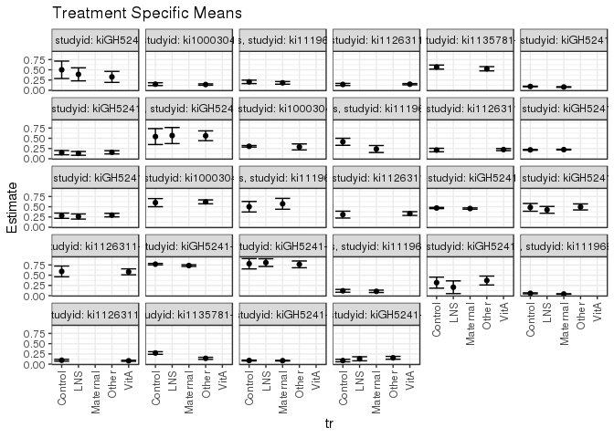

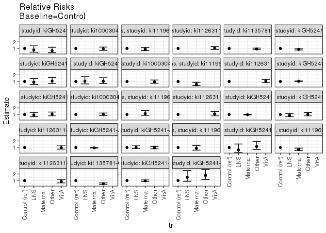

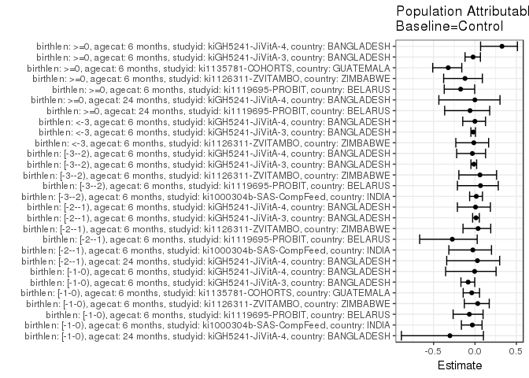

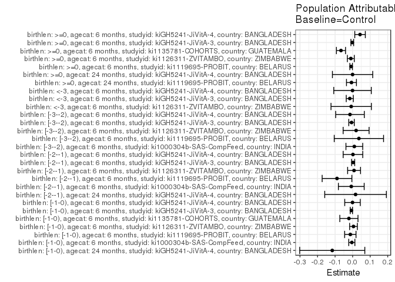

## Results Table

### Parameter: TSM

| birthlen | agecat | studyid | country | intervention_level | baseline_level | estimate | ci_lower | ci_upper |
| --- | --- | --- | --- | --- | --- | --- | --- | --- |
| >=0 | 6 months | ki1119695-PROBIT | BELARUS | Control | NA | 0.0574996 | 0.0459768 | 0.0690225 |
| >=0 | 6 months | ki1119695-PROBIT | BELARUS | Maternal | NA | 0.0407889 | 0.0344769 | 0.0471009 |
| >=0 | 6 months | ki1126311-ZVITAMBO | ZIMBABWE | Control | NA | 0.0948553 | 0.0718235 | 0.1178871 |
| >=0 | 6 months | ki1126311-ZVITAMBO | ZIMBABWE | VitA | NA | 0.0813893 | 0.0691849 | 0.0935937 |
| >=0 | 6 months | ki1135781-COHORTS | GUATEMALA | Control | NA | 0.2717391 | 0.2401582 | 0.3033201 |
| >=0 | 6 months | ki1135781-COHORTS | GUATEMALA | Other | NA | 0.1413613 | 0.1161622 | 0.1665603 |
| >=0 | 6 months | kiGH5241-JiVitA-3 | BANGLADESH | Control | NA | 0.0882353 | 0.0786461 | 0.0978245 |
| >=0 | 6 months | kiGH5241-JiVitA-3 | BANGLADESH | Maternal | NA | 0.0844884 | 0.0766812 | 0.0922957 |
| >=0 | 6 months | kiGH5241-JiVitA-4 | BANGLADESH | Control | NA | 0.0872093 | 0.0566555 | 0.1177631 |
| >=0 | 6 months | kiGH5241-JiVitA-4 | BANGLADESH | LNS | NA | 0.1301587 | 0.0803081 | 0.1800094 |
| >=0 | 6 months | kiGH5241-JiVitA-4 | BANGLADESH | Other | NA | 0.1546573 | 0.1200106 | 0.1893040 |
| >=0 | 24 months | ki1119695-PROBIT | BELARUS | Control | NA | 0.1186441 | 0.0844546 | 0.1528335 |
| >=0 | 24 months | ki1119695-PROBIT | BELARUS | Maternal | NA | 0.1064815 | 0.0777821 | 0.1351808 |
| >=0 | 24 months | kiGH5241-JiVitA-4 | BANGLADESH | Control | NA | 0.3181818 | 0.1835743 | 0.4527893 |
| >=0 | 24 months | kiGH5241-JiVitA-4 | BANGLADESH | LNS | NA | 0.2058824 | 0.0500624 | 0.3617023 |
| >=0 | 24 months | kiGH5241-JiVitA-4 | BANGLADESH | Other | NA | 0.3698630 | 0.2610148 | 0.4787113 |
| <-3 | 6 months | ki1126311-ZVITAMBO | ZIMBABWE | Control | NA | 0.5925926 | 0.4612560 | 0.7239292 |
| <-3 | 6 months | ki1126311-ZVITAMBO | ZIMBABWE | VitA | NA | 0.5819209 | 0.5090985 | 0.6547433 |
| <-3 | 6 months | kiGH5241-JiVitA-3 | BANGLADESH | Control | NA | 0.7696552 | 0.7516688 | 0.7876416 |
| <-3 | 6 months | kiGH5241-JiVitA-3 | BANGLADESH | Maternal | NA | 0.7349206 | 0.7147676 | 0.7550737 |
| <-3 | 6 months | kiGH5241-JiVitA-4 | BANGLADESH | Control | NA | 0.7800000 | 0.6534121 | 0.9065879 |
| <-3 | 6 months | kiGH5241-JiVitA-4 | BANGLADESH | LNS | NA | 0.8076923 | 0.7138950 | 0.9014896 |
| <-3 | 6 months | kiGH5241-JiVitA-4 | BANGLADESH | Other | NA | 0.7647059 | 0.6816090 | 0.8478028 |
| [-3–2) | 6 months | ki1000304b-SAS-CompFeed | INDIA | Control | NA | 0.6000000 | 0.5007597 | 0.6992403 |
| [-3–2) | 6 months | ki1000304b-SAS-CompFeed | INDIA | Other | NA | 0.6190476 | 0.5711821 | 0.6669131 |
| [-3–2) | 6 months | ki1119695-PROBIT | BELARUS | Control | NA | 0.5000000 | 0.3717668 | 0.6282332 |
| [-3–2) | 6 months | ki1119695-PROBIT | BELARUS | Maternal | NA | 0.5714286 | 0.4387371 | 0.7041200 |
| [-3–2) | 6 months | ki1126311-ZVITAMBO | ZIMBABWE | Control | NA | 0.3076923 | 0.2239810 | 0.3914036 |
| [-3–2) | 6 months | ki1126311-ZVITAMBO | ZIMBABWE | VitA | NA | 0.3333333 | 0.2870338 | 0.3796329 |
| [-3–2) | 6 months | kiGH5241-JiVitA-3 | BANGLADESH | Control | NA | 0.4689379 | 0.4543296 | 0.4835461 |
| [-3–2) | 6 months | kiGH5241-JiVitA-3 | BANGLADESH | Maternal | NA | 0.4562842 | 0.4406382 | 0.4719301 |
| [-3–2) | 6 months | kiGH5241-JiVitA-4 | BANGLADESH | Control | NA | 0.4848485 | 0.3901881 | 0.5795089 |
| [-3–2) | 6 months | kiGH5241-JiVitA-4 | BANGLADESH | LNS | NA | 0.4242424 | 0.3412962 | 0.5071886 |
| [-3–2) | 6 months | kiGH5241-JiVitA-4 | BANGLADESH | Other | NA | 0.4954128 | 0.4216851 | 0.5691406 |
| [-2–1) | 6 months | ki1000304b-SAS-CompFeed | INDIA | Control | NA | 0.3033708 | 0.2852949 | 0.3214466 |
| [-2–1) | 6 months | ki1000304b-SAS-CompFeed | INDIA | Other | NA | 0.2886598 | 0.2157252 | 0.3615944 |
| [-2–1) | 6 months | ki1119695-PROBIT | BELARUS | Control | NA | 0.4137931 | 0.3275705 | 0.5000157 |
| [-2–1) | 6 months | ki1119695-PROBIT | BELARUS | Maternal | NA | 0.2372881 | 0.1522280 | 0.3223483 |
| [-2–1) | 6 months | ki1126311-ZVITAMBO | ZIMBABWE | Control | NA | 0.2122905 | 0.1699156 | 0.2546654 |
| [-2–1) | 6 months | ki1126311-ZVITAMBO | ZIMBABWE | VitA | NA | 0.2233840 | 0.1982059 | 0.2485622 |
| [-2–1) | 6 months | kiGH5241-JiVitA-3 | BANGLADESH | Control | NA | 0.2166990 | 0.2068592 | 0.2265388 |
| [-2–1) | 6 months | kiGH5241-JiVitA-3 | BANGLADESH | Maternal | NA | 0.2224409 | 0.2134505 | 0.2314314 |
| [-2–1) | 6 months | kiGH5241-JiVitA-4 | BANGLADESH | Control | NA | 0.2803347 | 0.2160780 | 0.3445914 |
| [-2–1) | 6 months | kiGH5241-JiVitA-4 | BANGLADESH | LNS | NA | 0.2608696 | 0.1978432 | 0.3238959 |
| [-2–1) | 6 months | kiGH5241-JiVitA-4 | BANGLADESH | Other | NA | 0.2954545 | 0.2524682 | 0.3384409 |
| [-2–1) | 24 months | kiGH5241-JiVitA-4 | BANGLADESH | Control | NA | 0.5416667 | 0.3470038 | 0.7363295 |
| [-2–1) | 24 months | kiGH5241-JiVitA-4 | BANGLADESH | LNS | NA | 0.5666667 | 0.3701371 | 0.7631962 |
| [-2–1) | 24 months | kiGH5241-JiVitA-4 | BANGLADESH | Other | NA | 0.5606061 | 0.4409730 | 0.6802391 |
| [-1-0) | 6 months | ki1000304b-SAS-CompFeed | INDIA | Control | NA | 0.1495327 | 0.1146602 | 0.1844052 |
| [-1-0) | 6 months | ki1000304b-SAS-CompFeed | INDIA | Other | NA | 0.1400000 | 0.1233814 | 0.1566186 |
| [-1-0) | 6 months | ki1119695-PROBIT | BELARUS | Control | NA | 0.2055046 | 0.1635379 | 0.2474713 |
| [-1-0) | 6 months | ki1119695-PROBIT | BELARUS | Maternal | NA | 0.1809370 | 0.1483890 | 0.2134850 |
| [-1-0) | 6 months | ki1126311-ZVITAMBO | ZIMBABWE | Control | NA | 0.1420765 | 0.1167805 | 0.1673725 |
| [-1-0) | 6 months | ki1126311-ZVITAMBO | ZIMBABWE | VitA | NA | 0.1486670 | 0.1338422 | 0.1634917 |
| [-1-0) | 6 months | ki1135781-COHORTS | GUATEMALA | Control | NA | 0.5666667 | 0.5172621 | 0.6160712 |
| [-1-0) | 6 months | ki1135781-COHORTS | GUATEMALA | Other | NA | 0.5257732 | 0.4740900 | 0.5774563 |
| [-1-0) | 6 months | kiGH5241-JiVitA-3 | BANGLADESH | Control | NA | 0.0930824 | 0.0860747 | 0.1000901 |
| [-1-0) | 6 months | kiGH5241-JiVitA-3 | BANGLADESH | Maternal | NA | 0.0794021 | 0.0728312 | 0.0859731 |
| [-1-0) | 6 months | kiGH5241-JiVitA-4 | BANGLADESH | Control | NA | 0.1481481 | 0.0960722 | 0.2002241 |
| [-1-0) | 6 months | kiGH5241-JiVitA-4 | BANGLADESH | LNS | NA | 0.1309091 | 0.0845871 | 0.1772310 |
| [-1-0) | 6 months | kiGH5241-JiVitA-4 | BANGLADESH | Other | NA | 0.1567797 | 0.1169848 | 0.1965746 |
| [-1-0) | 24 months | kiGH5241-JiVitA-4 | BANGLADESH | Control | NA | 0.5000000 | 0.2872844 | 0.7127156 |
| [-1-0) | 24 months | kiGH5241-JiVitA-4 | BANGLADESH | LNS | NA | 0.3888889 | 0.2294156 | 0.5483621 |
| [-1-0) | 24 months | kiGH5241-JiVitA-4 | BANGLADESH | Other | NA | 0.3269231 | 0.1927194 | 0.4611267 |

### Parameter: E(Y)

| birthlen | agecat | studyid | country | intervention_level | baseline_level | estimate | ci_lower | ci_upper |
| --- | --- | --- | --- | --- | --- | --- | --- | --- |
| >=0 | 6 months | ki1119695-PROBIT | BELARUS | NA | NA | 0.0490137 | 0.0349538 | 0.0630735 |
| >=0 | 6 months | ki1126311-ZVITAMBO | ZIMBABWE | NA | NA | 0.0846727 | 0.0738674 | 0.0954780 |
| >=0 | 6 months | ki1135781-COHORTS | GUATEMALA | NA | NA | 0.2053333 | 0.1643946 | 0.2462721 |
| >=0 | 6 months | kiGH5241-JiVitA-3 | BANGLADESH | NA | NA | 0.0862609 | 0.0738842 | 0.0986376 |
| >=0 | 6 months | kiGH5241-JiVitA-4 | BANGLADESH | NA | NA | 0.1294788 | 0.1070395 | 0.1519182 |
| >=0 | 24 months | ki1119695-PROBIT | BELARUS | NA | NA | 0.1119593 | 0.0676454 | 0.1562732 |
| >=0 | 24 months | kiGH5241-JiVitA-4 | BANGLADESH | NA | NA | 0.3178808 | 0.2428176 | 0.3929440 |
| <-3 | 6 months | ki1126311-ZVITAMBO | ZIMBABWE | NA | NA | 0.5844156 | 0.5207251 | 0.6481061 |
| <-3 | 6 months | kiGH5241-JiVitA-3 | BANGLADESH | NA | NA | 0.7535055 | 0.7264069 | 0.7806042 |
| <-3 | 6 months | kiGH5241-JiVitA-4 | BANGLADESH | NA | NA | 0.7794118 | 0.7222124 | 0.8366111 |
| [-3–2) | 6 months | ki1000304b-SAS-CompFeed | INDIA | NA | NA | 0.6097561 | 0.5007125 | 0.7187997 |
| [-3–2) | 6 months | ki1119695-PROBIT | BELARUS | NA | NA | 0.5357143 | 0.3370878 | 0.7343408 |
| [-3–2) | 6 months | ki1126311-ZVITAMBO | ZIMBABWE | NA | NA | 0.3275194 | 0.2869869 | 0.3680518 |
| [-3–2) | 6 months | kiGH5241-JiVitA-3 | BANGLADESH | NA | NA | 0.4626815 | 0.4412495 | 0.4841135 |
| [-3–2) | 6 months | kiGH5241-JiVitA-4 | BANGLADESH | NA | NA | 0.4699029 | 0.4221505 | 0.5176554 |
| [-2–1) | 6 months | ki1000304b-SAS-CompFeed | INDIA | NA | NA | 0.2956989 | 0.2200147 | 0.3713832 |
| [-2–1) | 6 months | ki1119695-PROBIT | BELARUS | NA | NA | 0.3247863 | 0.2011604 | 0.4484123 |
| [-2–1) | 6 months | ki1126311-ZVITAMBO | ZIMBABWE | NA | NA | 0.2205674 | 0.1989176 | 0.2422171 |
| [-2–1) | 6 months | kiGH5241-JiVitA-3 | BANGLADESH | NA | NA | 0.2195503 | 0.2062235 | 0.2328772 |
| [-2–1) | 6 months | kiGH5241-JiVitA-4 | BANGLADESH | NA | NA | 0.2822823 | 0.2511086 | 0.3134560 |
| [-2–1) | 24 months | kiGH5241-JiVitA-4 | BANGLADESH | NA | NA | 0.5583333 | 0.4672504 | 0.6494162 |
| [-1-0) | 6 months | ki1000304b-SAS-CompFeed | INDIA | NA | NA | 0.1449275 | 0.1055444 | 0.1843107 |
| [-1-0) | 6 months | ki1119695-PROBIT | BELARUS | NA | NA | 0.1924399 | 0.1393401 | 0.2455397 |
| [-1-0) | 6 months | ki1126311-ZVITAMBO | ZIMBABWE | NA | NA | 0.1470289 | 0.1342366 | 0.1598211 |
| [-1-0) | 6 months | ki1135781-COHORTS | GUATEMALA | NA | NA | 0.5454545 | 0.4738963 | 0.6170128 |
| [-1-0) | 6 months | kiGH5241-JiVitA-3 | BANGLADESH | NA | NA | 0.0859508 | 0.0763332 | 0.0955684 |
| [-1-0) | 6 months | kiGH5241-JiVitA-4 | BANGLADESH | NA | NA | 0.1474926 | 0.1212333 | 0.1737519 |
| [-1-0) | 24 months | kiGH5241-JiVitA-4 | BANGLADESH | NA | NA | 0.3839286 | 0.2903248 | 0.4775324 |

### Parameter: RR

| birthlen | agecat | studyid | country | intervention_level | baseline_level | estimate | ci_lower | ci_upper |
| --- | --- | --- | --- | --- | --- | --- | --- | --- |
| >=0 | 6 months | ki1119695-PROBIT | BELARUS | Control | Control | 1.0000000 | 1.0000000 | 1.0000000 |
| >=0 | 6 months | ki1119695-PROBIT | BELARUS | Maternal | Control | 0.7093766 | 0.5518602 | 0.9118528 |
| >=0 | 6 months | ki1126311-ZVITAMBO | ZIMBABWE | Control | Control | 1.0000000 | 1.0000000 | 1.0000000 |
| >=0 | 6 months | ki1126311-ZVITAMBO | ZIMBABWE | VitA | Control | 0.8580366 | 0.6450104 | 1.1414184 |
| >=0 | 6 months | ki1135781-COHORTS | GUATEMALA | Control | Control | 1.0000000 | 1.0000000 | 1.0000000 |
| >=0 | 6 months | ki1135781-COHORTS | GUATEMALA | Other | Control | 0.5202094 | 0.4204952 | 0.6435694 |
| >=0 | 6 months | kiGH5241-JiVitA-3 | BANGLADESH | Control | Control | 1.0000000 | 1.0000000 | 1.0000000 |
| >=0 | 6 months | kiGH5241-JiVitA-3 | BANGLADESH | Maternal | Control | 0.9575358 | 0.8302801 | 1.1042957 |
| >=0 | 6 months | kiGH5241-JiVitA-4 | BANGLADESH | Control | Control | 1.0000000 | 1.0000000 | 1.0000000 |
| >=0 | 6 months | kiGH5241-JiVitA-4 | BANGLADESH | LNS | Control | 1.4924868 | 0.8882583 | 2.5077354 |
| >=0 | 6 months | kiGH5241-JiVitA-4 | BANGLADESH | Other | Control | 1.7734036 | 1.1700852 | 2.6878046 |
| >=0 | 24 months | ki1119695-PROBIT | BELARUS | Control | Control | 1.0000000 | 1.0000000 | 1.0000000 |
| >=0 | 24 months | ki1119695-PROBIT | BELARUS | Maternal | Control | 0.8974868 | 0.6036615 | 1.3343281 |
| >=0 | 24 months | kiGH5241-JiVitA-4 | BANGLADESH | Control | Control | 1.0000000 | 1.0000000 | 1.0000000 |
| >=0 | 24 months | kiGH5241-JiVitA-4 | BANGLADESH | LNS | Control | 0.6470588 | 0.2718977 | 1.5398629 |
| >=0 | 24 months | kiGH5241-JiVitA-4 | BANGLADESH | Other | Control | 1.1624266 | 0.6941927 | 1.9464851 |
| <-3 | 6 months | ki1126311-ZVITAMBO | ZIMBABWE | Control | Control | 1.0000000 | 1.0000000 | 1.0000000 |
| <-3 | 6 months | ki1126311-ZVITAMBO | ZIMBABWE | VitA | Control | 0.9819915 | 0.7613267 | 1.2666143 |
| <-3 | 6 months | kiGH5241-JiVitA-3 | BANGLADESH | Control | Control | 1.0000000 | 1.0000000 | 1.0000000 |
| <-3 | 6 months | kiGH5241-JiVitA-3 | BANGLADESH | Maternal | Control | 0.9548700 | 0.9210848 | 0.9898944 |
| <-3 | 6 months | kiGH5241-JiVitA-4 | BANGLADESH | Control | Control | 1.0000000 | 1.0000000 | 1.0000000 |
| <-3 | 6 months | kiGH5241-JiVitA-4 | BANGLADESH | LNS | Control | 1.0355030 | 0.8482063 | 1.2641575 |
| <-3 | 6 months | kiGH5241-JiVitA-4 | BANGLADESH | Other | Control | 0.9803922 | 0.8064657 | 1.1918285 |
| [-3–2) | 6 months | ki1000304b-SAS-CompFeed | INDIA | Control | Control | 1.0000000 | 1.0000000 | 1.0000000 |
| [-3–2) | 6 months | ki1000304b-SAS-CompFeed | INDIA | Other | Control | 1.0317460 | 0.8610590 | 1.2362683 |
| [-3–2) | 6 months | ki1119695-PROBIT | BELARUS | Control | Control | 1.0000000 | 1.0000000 | 1.0000000 |
| [-3–2) | 6 months | ki1119695-PROBIT | BELARUS | Maternal | Control | 1.1428571 | 0.8186386 | 1.5954812 |
| [-3–2) | 6 months | ki1126311-ZVITAMBO | ZIMBABWE | Control | Control | 1.0000000 | 1.0000000 | 1.0000000 |
| [-3–2) | 6 months | ki1126311-ZVITAMBO | ZIMBABWE | VitA | Control | 1.0833333 | 0.7981770 | 1.4703645 |
| [-3–2) | 6 months | kiGH5241-JiVitA-3 | BANGLADESH | Control | Control | 1.0000000 | 1.0000000 | 1.0000000 |
| [-3–2) | 6 months | kiGH5241-JiVitA-3 | BANGLADESH | Maternal | Control | 0.9730162 | 0.9289723 | 1.0191483 |
| [-3–2) | 6 months | kiGH5241-JiVitA-4 | BANGLADESH | Control | Control | 1.0000000 | 1.0000000 | 1.0000000 |
| [-3–2) | 6 months | kiGH5241-JiVitA-4 | BANGLADESH | LNS | Control | 0.8750000 | 0.6636615 | 1.1536377 |
| [-3–2) | 6 months | kiGH5241-JiVitA-4 | BANGLADESH | Other | Control | 1.0217890 | 0.7993234 | 1.3061706 |
| [-2–1) | 6 months | ki1000304b-SAS-CompFeed | INDIA | Control | Control | 1.0000000 | 1.0000000 | 1.0000000 |
| [-2–1) | 6 months | ki1000304b-SAS-CompFeed | INDIA | Other | Control | 0.9515082 | 0.7339508 | 1.2335538 |
| [-2–1) | 6 months | ki1119695-PROBIT | BELARUS | Control | Control | 1.0000000 | 1.0000000 | 1.0000000 |
| [-2–1) | 6 months | ki1119695-PROBIT | BELARUS | Maternal | Control | 0.5734463 | 0.3753423 | 0.8761088 |
| [-2–1) | 6 months | ki1126311-ZVITAMBO | ZIMBABWE | Control | Control | 1.0000000 | 1.0000000 | 1.0000000 |
| [-2–1) | 6 months | ki1126311-ZVITAMBO | ZIMBABWE | VitA | Control | 1.0522564 | 0.8366950 | 1.3233537 |
| [-2–1) | 6 months | kiGH5241-JiVitA-3 | BANGLADESH | Control | Control | 1.0000000 | 1.0000000 | 1.0000000 |
| [-2–1) | 6 months | kiGH5241-JiVitA-3 | BANGLADESH | Maternal | Control | 1.0264972 | 0.9659487 | 1.0908411 |
| [-2–1) | 6 months | kiGH5241-JiVitA-4 | BANGLADESH | Control | Control | 1.0000000 | 1.0000000 | 1.0000000 |
| [-2–1) | 6 months | kiGH5241-JiVitA-4 | BANGLADESH | LNS | Control | 0.9305646 | 0.6670537 | 1.2981719 |
| [-2–1) | 6 months | kiGH5241-JiVitA-4 | BANGLADESH | Other | Control | 1.0539349 | 0.8032661 | 1.3828277 |
| [-2–1) | 24 months | kiGH5241-JiVitA-4 | BANGLADESH | Control | Control | 1.0000000 | 1.0000000 | 1.0000000 |
| [-2–1) | 24 months | kiGH5241-JiVitA-4 | BANGLADESH | LNS | Control | 1.0461538 | 0.6349076 | 1.7237749 |
| [-2–1) | 24 months | kiGH5241-JiVitA-4 | BANGLADESH | Other | Control | 1.0349650 | 0.6818055 | 1.5710531 |
| [-1-0) | 6 months | ki1000304b-SAS-CompFeed | INDIA | Control | Control | 1.0000000 | 1.0000000 | 1.0000000 |
| [-1-0) | 6 months | ki1000304b-SAS-CompFeed | INDIA | Other | Control | 0.9362500 | 0.7214551 | 1.2149946 |
| [-1-0) | 6 months | ki1119695-PROBIT | BELARUS | Control | Control | 1.0000000 | 1.0000000 | 1.0000000 |
| [-1-0) | 6 months | ki1119695-PROBIT | BELARUS | Maternal | Control | 0.8804523 | 0.6674699 | 1.1613952 |
| [-1-0) | 6 months | ki1126311-ZVITAMBO | ZIMBABWE | Control | Control | 1.0000000 | 1.0000000 | 1.0000000 |
| [-1-0) | 6 months | ki1126311-ZVITAMBO | ZIMBABWE | VitA | Control | 1.0463867 | 0.8532312 | 1.2832691 |
| [-1-0) | 6 months | ki1135781-COHORTS | GUATEMALA | Control | Control | 1.0000000 | 1.0000000 | 1.0000000 |
| [-1-0) | 6 months | ki1135781-COHORTS | GUATEMALA | Other | Control | 0.9278351 | 0.8135943 | 1.0581169 |
| [-1-0) | 6 months | kiGH5241-JiVitA-3 | BANGLADESH | Control | Control | 1.0000000 | 1.0000000 | 1.0000000 |
| [-1-0) | 6 months | kiGH5241-JiVitA-3 | BANGLADESH | Maternal | Control | 0.8530307 | 0.7627428 | 0.9540063 |
| [-1-0) | 6 months | kiGH5241-JiVitA-4 | BANGLADESH | Control | Control | 1.0000000 | 1.0000000 | 1.0000000 |
| [-1-0) | 6 months | kiGH5241-JiVitA-4 | BANGLADESH | LNS | Control | 0.8836364 | 0.5365854 | 1.4551519 |
| [-1-0) | 6 months | kiGH5241-JiVitA-4 | BANGLADESH | Other | Control | 1.0582627 | 0.6859364 | 1.6326877 |
| [-1-0) | 24 months | kiGH5241-JiVitA-4 | BANGLADESH | Control | Control | 1.0000000 | 1.0000000 | 1.0000000 |
| [-1-0) | 24 months | kiGH5241-JiVitA-4 | BANGLADESH | LNS | Control | 0.7777778 | 0.4308622 | 1.4040181 |
| [-1-0) | 24 months | kiGH5241-JiVitA-4 | BANGLADESH | Other | Control | 0.6538462 | 0.3619291 | 1.1812116 |

### Parameter: PAR

| birthlen | agecat | studyid | country | intervention_level | baseline_level | estimate | ci_lower | ci_upper |
| --- | --- | --- | --- | --- | --- | --- | --- | --- |
| >=0 | 6 months | ki1119695-PROBIT | BELARUS | Control | NA | -0.0084860 | -0.0158429 | -0.0011291 |
| >=0 | 6 months | ki1126311-ZVITAMBO | ZIMBABWE | Control | NA | -0.0101826 | -0.0298940 | 0.0095287 |
| >=0 | 6 months | ki1135781-COHORTS | GUATEMALA | Control | NA | -0.0664058 | -0.0924562 | -0.0403554 |
| >=0 | 6 months | kiGH5241-JiVitA-3 | BANGLADESH | Control | NA | -0.0019744 | -0.0097881 | 0.0058393 |
| >=0 | 6 months | kiGH5241-JiVitA-4 | BANGLADESH | Control | NA | 0.0422695 | 0.0122079 | 0.0723312 |
| >=0 | 24 months | ki1119695-PROBIT | BELARUS | Control | NA | -0.0066848 | -0.0350775 | 0.0217079 |
| >=0 | 24 months | kiGH5241-JiVitA-4 | BANGLADESH | Control | NA | -0.0003010 | -0.1152241 | 0.1146221 |
| <-3 | 6 months | ki1126311-ZVITAMBO | ZIMBABWE | Control | NA | -0.0081770 | -0.1232473 | 0.1068933 |
| <-3 | 6 months | kiGH5241-JiVitA-3 | BANGLADESH | Control | NA | -0.0161496 | -0.0363869 | 0.0040876 |
| <-3 | 6 months | kiGH5241-JiVitA-4 | BANGLADESH | Control | NA | -0.0005882 | -0.1075290 | 0.1063525 |
| [-3–2) | 6 months | ki1000304b-SAS-CompFeed | INDIA | Control | NA | 0.0097561 | -0.0381271 | 0.0576393 |
| [-3–2) | 6 months | ki1119695-PROBIT | BELARUS | Control | NA | 0.0357143 | -0.1048471 | 0.1762757 |
| [-3–2) | 6 months | ki1126311-ZVITAMBO | ZIMBABWE | Control | NA | 0.0198271 | -0.0541500 | 0.0938042 |
| [-3–2) | 6 months | kiGH5241-JiVitA-3 | BANGLADESH | Control | NA | -0.0062563 | -0.0219322 | 0.0094195 |
| [-3–2) | 6 months | kiGH5241-JiVitA-4 | BANGLADESH | Control | NA | -0.0149456 | -0.0965942 | 0.0667030 |
| [-2–1) | 6 months | ki1000304b-SAS-CompFeed | INDIA | Control | NA | -0.0076719 | -0.0811721 | 0.0658284 |
| [-2–1) | 6 months | ki1119695-PROBIT | BELARUS | Control | NA | -0.0890068 | -0.1736844 | -0.0043292 |
| [-2–1) | 6 months | ki1126311-ZVITAMBO | ZIMBABWE | Control | NA | 0.0082769 | -0.0284997 | 0.0450535 |
| [-2–1) | 6 months | kiGH5241-JiVitA-3 | BANGLADESH | Control | NA | 0.0028513 | -0.0061445 | 0.0118471 |
| [-2–1) | 6 months | kiGH5241-JiVitA-4 | BANGLADESH | Control | NA | 0.0019476 | -0.0539594 | 0.0578545 |
| [-2–1) | 24 months | kiGH5241-JiVitA-4 | BANGLADESH | Control | NA | 0.0166667 | -0.1590319 | 0.1923653 |
| [-1-0) | 6 months | ki1000304b-SAS-CompFeed | INDIA | Control | NA | -0.0046052 | -0.0220175 | 0.0128071 |
| [-1-0) | 6 months | ki1119695-PROBIT | BELARUS | Control | NA | -0.0130647 | -0.0453824 | 0.0192529 |
| [-1-0) | 6 months | ki1126311-ZVITAMBO | ZIMBABWE | Control | NA | 0.0049524 | -0.0170802 | 0.0269849 |
| [-1-0) | 6 months | ki1135781-COHORTS | GUATEMALA | Control | NA | -0.0212121 | -0.0729786 | 0.0305544 |
| [-1-0) | 6 months | kiGH5241-JiVitA-3 | BANGLADESH | Control | NA | -0.0071316 | -0.0137237 | -0.0005395 |
| [-1-0) | 6 months | kiGH5241-JiVitA-4 | BANGLADESH | Control | NA | -0.0006555 | -0.0449491 | 0.0436381 |
| [-1-0) | 24 months | kiGH5241-JiVitA-4 | BANGLADESH | Control | NA | -0.1160714 | -0.3015687 | 0.0694258 |

### Parameter: PAF

| birthlen | agecat | studyid | country | intervention_level | baseline_level | estimate | ci_lower | ci_upper |
| --- | --- | --- | --- | --- | --- | --- | --- | --- |
| >=0 | 6 months | ki1119695-PROBIT | BELARUS | Control | NA | -0.1731346 | -0.3714526 | -0.0034942 |
| >=0 | 6 months | ki1126311-ZVITAMBO | ZIMBABWE | Control | NA | -0.1202587 | -0.3785135 | 0.0896139 |
| >=0 | 6 months | ki1135781-COHORTS | GUATEMALA | Control | NA | -0.3234049 | -0.5106305 | -0.1593837 |
| >=0 | 6 months | kiGH5241-JiVitA-3 | BANGLADESH | Control | NA | -0.0228890 | -0.1199123 | 0.0657287 |
| >=0 | 6 months | kiGH5241-JiVitA-4 | BANGLADESH | Control | NA | 0.3264590 | 0.0679122 | 0.5132889 |
| >=0 | 24 months | ki1119695-PROBIT | BELARUS | Control | NA | -0.0597072 | -0.3662552 | 0.1780603 |
| >=0 | 24 months | kiGH5241-JiVitA-4 | BANGLADESH | Control | NA | -0.0009470 | -0.4364040 | 0.3024979 |
| <-3 | 6 months | ki1126311-ZVITAMBO | ZIMBABWE | Control | NA | -0.0139918 | -0.2313200 | 0.1649780 |
| <-3 | 6 months | kiGH5241-JiVitA-3 | BANGLADESH | Control | NA | -0.0214327 | -0.0492433 | 0.0056408 |
| <-3 | 6 months | kiGH5241-JiVitA-4 | BANGLADESH | Control | NA | -0.0007547 | -0.1478056 | 0.1274568 |
| [-3–2) | 6 months | ki1000304b-SAS-CompFeed | INDIA | Control | NA | 0.0160000 | -0.0645088 | 0.0904199 |
| [-3–2) | 6 months | ki1119695-PROBIT | BELARUS | Control | NA | 0.0666667 | -0.2121572 | 0.2813547 |
| [-3–2) | 6 months | ki1126311-ZVITAMBO | ZIMBABWE | Control | NA | 0.0605371 | -0.1947863 | 0.2612984 |
| [-3–2) | 6 months | kiGH5241-JiVitA-3 | BANGLADESH | Control | NA | -0.0135219 | -0.0484518 | 0.0202442 |
| [-3–2) | 6 months | kiGH5241-JiVitA-4 | BANGLADESH | Control | NA | -0.0318057 | -0.2210781 | 0.1281287 |
| [-2–1) | 6 months | ki1000304b-SAS-CompFeed | INDIA | Control | NA | -0.0259448 | -0.3154552 | 0.1998490 |
| [-2–1) | 6 months | ki1119695-PROBIT | BELARUS | Control | NA | -0.2740472 | -0.6680864 | 0.0269112 |
| [-2–1) | 6 months | ki1126311-ZVITAMBO | ZIMBABWE | Control | NA | 0.0375254 | -0.1445029 | 0.1906028 |
| [-2–1) | 6 months | kiGH5241-JiVitA-3 | BANGLADESH | Control | NA | 0.0129871 | -0.0282993 | 0.0526158 |
| [-2–1) | 6 months | kiGH5241-JiVitA-4 | BANGLADESH | Control | NA | 0.0068993 | -0.2122940 | 0.1864606 |
| [-2–1) | 24 months | kiGH5241-JiVitA-4 | BANGLADESH | Control | NA | 0.0298507 | -0.3416504 | 0.2984837 |
| [-1-0) | 6 months | ki1000304b-SAS-CompFeed | INDIA | Control | NA | -0.0317757 | -0.1639829 | 0.0854152 |
| [-1-0) | 6 months | ki1119695-PROBIT | BELARUS | Control | NA | -0.0678899 | -0.2639775 | 0.0977776 |
| [-1-0) | 6 months | ki1126311-ZVITAMBO | ZIMBABWE | Control | NA | 0.0336829 | -0.1283903 | 0.1724772 |
| [-1-0) | 6 months | ki1135781-COHORTS | GUATEMALA | Control | NA | -0.0388889 | -0.1423843 | 0.0552302 |
| [-1-0) | 6 months | kiGH5241-JiVitA-3 | BANGLADESH | Control | NA | -0.0829729 | -0.1695930 | -0.0027678 |
| [-1-0) | 6 months | kiGH5241-JiVitA-4 | BANGLADESH | Control | NA | -0.0044444 | -0.3544520 | 0.2551167 |
| [-1-0) | 24 months | kiGH5241-JiVitA-4 | BANGLADESH | Control | NA | -0.3023256 | -0.8890553 | 0.1021693 |